# 200731-practice

Nougaga

2020 7 31

[R Markdown Guide](https://rstudio.com/wp-content/uploads/2015/03/rmarkdown-reference.pdf?_ga=2.131128839.981889577.1596078609-636090901.1596078609)

## **Array**

다차원 구조를 가진 데이터를 만들 때 사용

vector는 1차원 array, matrix는 2차원 array

array로 3차원 이상의 데이터 구조를 만들 수 있다.

```r
arr1 <- array(1:12, dim=c(3,4))
arr1
```

```
##      [,1] [,2] [,3] [,4]
## [1,]    1    4    7   10
## [2,]    2    5    8   11
## [3,]    3    6    9   12
```

```r
arr2 <- array(1:12, dim=c(3,4), dimnames=list(c('r1','r2','r3'),c('c1','c2','c3','c4')))
arr2
```

```
##    c1 c2 c3 c4
## r1  1  4  7 10
## r2  2  5  8 11
## r3  3  6  9 12
```

2차원 구조의 array는 matrix와 구조가 같다.

```r
mat1 <- matrix(1:12, nrow=3)
mat1
```

```
##      [,1] [,2] [,3] [,4]
## [1,]    1    4    7   10
## [2,]    2    5    8   11
## [3,]    3    6    9   12
```

```r
mat2 <- matrix(1:12, nrow=3, dimnames=list(c('r1','r2','r3'),c('c1','c2','c3','c4')))
mat2
```

```
##    c1 c2 c3 c4
## r1  1  4  7 10
## r2  2  5  8 11
## r3  3  6  9 12
```

3차원 array

```r
arr3 <- array(1:12,dim=c(2,2,3))
arr3
```

```
## , , 1
##
##      [,1] [,2]
## [1,]    1    3
## [2,]    2    4
##
## , , 2
##
##      [,1] [,2]
## [1,]    5    7
## [2,]    6    8
##
## , , 3
##
##      [,1] [,2]
## [1,]    9   11
## [2,]   10   12
```

## **List**

key-value 구조

```r
a <- list(name='GilDong', age=30, job='SalesManager')
a
```

```
## $name
## [1] "GilDong"
##
## $age
## [1] 30
##
## $job
## [1] "SalesManager"
```

List는 성분의 길이가 같지 않아도 생성이 가능하다.

```r
b <- list(1:3, 'a', c(TRUE,FALSE,TRUE), c(2.3,5,9))
b
```

```
## [[1]]
## [1] 1 2 3
##
## [[2]]
## [1] "a"
##
## [[3]]
## [1]  TRUE FALSE  TRUE
##
## [[4]]
## [1] 2.3 5.0 9.0
```

unlist()로 list 구조를 해제할 수 있다.

```r
c <- unlist(a)
c; str(c); class(c)
```

```
##           name            age            job
##      "GilDong"           "30" "SalesManager"
```

```
##  Named chr [1:3] "GilDong" "30" "SalesManager"
##  - attr(*, "names")= chr [1:3] "name" "age" "job"
```

```
## [1] "character"
```

이는 아래와 같이 vector로도 표현할 수 있다.

```r
d <- c('Gildong',30,'SalesManager')
names(d) <- c('name','age','job')
d
```

```
##           name            age            job
##      "Gildong"           "30" "SalesManager"
```

## **Data frame**

```r
df <- data.frame(name='GilDong', age=20, job='SalesManager')
df; str(df)
```

```
##      name age          job
## 1 GilDong  20 SalesManager
```

```
## 'data.frame':    1 obs. of  3 variables:
##  $ name: Factor w/ 1 level "GilDong": 1
##  $ age : num 20
##  $ job : Factor w/ 1 level "SalesManager": 1
```

```r
df1 <- data.frame(name='GilDong', age=20, job='SalesManager',
                  stringsAsFactors=FALSE) # 문자형을 factor형으로 취급하지 않음
df1; str(df1)
```

```
##      name age          job
## 1 GilDong  20 SalesManager
```

```
## 'data.frame':    1 obs. of  3 variables:
##  $ name: chr "GilDong"
##  $ age : num 20
##  $ job : chr "SalesManager"
```

column명 변경

```r
names(df1) <- c('Names','Age','Job')
names(df1)[1] <- 'NAMES'
names(df1)
```

```
## [1] "NAMES" "Age"   "Job"
```

데이터 타입(4가지):

- 수치형(numeric: integer, double, …)
- 문자열형(character)
- 범주형(factor)
- 논리형(logical)

데이터 구조(5가지):

- vector
- matrix
- array
- list
- data frame

참고자료: http://adv-r.had.co.nz/Data-structures.html

matrix의 인덱싱

```r
mat <- matrix(1:9, nrow=3, dimnames=list(c('a1','a2','a3'),c('b1','b2','b3')))

# 2행 2열
mat[2,2]
mat['a2','b2']

# 모든 행과 2,3열
mat[1:3,2:3]
mat[1:3,-1] # -1 : 1열을 제외함
mat[,-1]
mat[c('a1','a2','a3'),c('b2','b3')]

# 2,3행과 1,2열
mat[2:3,1:2]
mat[-1,-3]
mat[c('a2','a3'),c('b1','b2')]
```

array의 인덱싱

```r
arr <- array(1:12, dim=c(2,2,3))

# 첫 번째 matrix, 모든 행, 2열
arr[,2,1]

# 세 번째 matrix, 1행, 1열
arr[1,1,3]

# 모든 매트릭스, 2행, 2열
arr[2,2,]
```

list의 인덱싱

```r
li <- list(name=c('GilDong', 'SeDol'),
           age=c(30,35),
           job=c('SalesManager','GoPro'))

# 첫 번째 키(name)의 두 번째 성분 = "SeDol"
li[[1]][2]
li$name[2]
```

```r
li <- list(name=c('GilDong', 'SeDol'),
           age=c(30,35),
           job=c('SalesManager','GoPro'))
li
```

```
## $name
## [1] "GilDong" "SeDol"
##
## $age
## [1] 30 35
##
## $job
## [1] "SalesManager" "GoPro"
```

data frame에서 접근방법

- matrix처럼 [,]
- list처럼 $

```r
df <- data.frame(name=c('GilDong', 'SeDol'),
                 age=c(30,35),
                 job=c('SalesManager','GoPro'))

df[,1]
```

```
## [1] GilDong SeDol
## Levels: GilDong SeDol
```

```r
df[,'name']
```

```
## [1] GilDong SeDol
## Levels: GilDong SeDol
```

```r
df$name
```

```
## [1] GilDong SeDol
## Levels: GilDong SeDol
```

```r
df$n  # df에서 제공하는 matching기능
```

```
## [1] GilDong SeDol
## Levels: GilDong SeDol
```

## **데이터를 다루는 기본 함수**

##### 대다수의 데이터가 수치, 문자열, 팩터 자료형을 혼합하여 가지고 있어서

> 우리가 다룰 데이터의 구조는 거의 data frame

```r
new_mem <- data.frame(name=c("heungMin", "HyunJin", "JiSung", "ChanHo"),
                      age=c(27,31,40,45),
                      job=c("FootballPlayer","BaseballPlayer","FootballPlayer","BaseballPlayeer"))
# 1. df에 행(사람) 추가
df <- rbind(df,new_mem)
df
# 2. df에 열(국적,도시) 추가
new_nat <- data.frame(nationality=c("Korea","Korea","Korea","Korea","Korea","Korea"))
df <- cbind(df,new_nat)
df$city <- c("한양","서울","토트넘","LA", "서울","서울")
df
```

```r
# bind, 데이터 수정 연습
df$surname = c("Hong", "Lee", "Son", "Ryu", "Park", "Park")
df$city <- c("Hanyang","Seoul","Tottenham","LA", "Seoul","Seoul")
df$age[1] <- 34
df$nationality <- as.character(df$nationality)
df$nationality[1]  <- "Chosun"
df
```

### Sorting

```r
a <- runif(10)
seque <- 1:10
a_df <- data.frame(num=a, sequence=seque)
b_df <- a_df[order(a_df$num, decreasing=T),]
a_df; b_df
```

```
##           num sequence
## 1  0.39012297        1
## 2  0.75763149        2
## 3  0.90768858        3
## 4  0.91425174        4
## 5  0.60704710        5
## 6  0.04029067        6
## 7  0.40956482        7
## 8  0.39922876        8
## 9  0.31768128        9
## 10 0.41350140       10
```

```
##           num sequence
## 4  0.91425174        4
## 3  0.90768858        3
## 2  0.75763149        2
## 5  0.60704710        5
## 10 0.41350140       10
## 7  0.40956482        7
## 8  0.39922876        8
## 1  0.39012297        1
## 9  0.31768128        9
## 6  0.04029067        6
```

# **데이터 불러오기**

```r
library(rJava)
library(xlsx)
```

### **텍스트 파일**

#### read.table로 불러오기

```r
student <- read.table(file='C:\\rsource\\data\\student.txt', sep="")  # header=F
student

# 작업 경로를 변경해서 파일 참조를 쉽게 하기
getwd()
setwd('C:/rsource/data'); getwd()

# header가 있을 때
student1 <- read.table(file='student1.txt', sep="", header=T, stringsAsFactors = F)
student1

# 데이터가 [Tab]이 아닌 다른 문자로 구분되어 있을 때
student2 <- read.table(file='student2.txt', sep=";", header=T, stringsAsFactors = F)
student2

# 파일 탐색기에서 직접 선택
student1_2 <- read.table(file=file.choose(), sep="", header=T, stringsAsFactors = F)
student1_2

student2; head(student2,2); tail(student2,2)
```

#### tibble 라이브러리를 이용하여 tibble data frame으로 표현

```r
# install.packages('tibble')
library(tibble)

iris_df <- iris

(iris_df1 <- as_tibble(iris_df))
```

```
## # A tibble: 150 x 5
##    Sepal.Length Sepal.Width Petal.Length Petal.Width Species
##           <dbl>       <dbl>        <dbl>       <dbl> <fct>
##  1          5.1         3.5          1.4         0.2 setosa
##  2          4.9         3            1.4         0.2 setosa
##  3          4.7         3.2          1.3         0.2 setosa
##  4          4.6         3.1          1.5         0.2 setosa
##  5          5           3.6          1.4         0.2 setosa
##  6          5.4         3.9          1.7         0.4 setosa
##  7          4.6         3.4          1.4         0.3 setosa
##  8          5           3.4          1.5         0.2 setosa
##  9          4.4         2.9          1.4         0.2 setosa
## 10          4.9         3.1          1.5         0.1 setosa
## # ... with 140 more rows
```

```r
?vignette
vignette('tibble')
```

#### 결측 데이터를 처리해서 불러오기

```r
(student3 <- read.table(file='C:\\rsource\\data\\student3.txt',
                       sep=" ", header=T,
                       na.strings="-"))  # '-'가 NA로 변환됨
```

```
##   번호 이름  키 몸무게
## 1  101 hong 175     NA
## 2  201  lee 185     85
## 3  301  kim 173     NA
## 4  401 park  NA     70
```

```r
(student4 <- read.table(file='C:\\rsource\\data\\student4.txt',
                       sep=",", header=T,
                       na.strings=c("-","+","$")))  # '-'가 NA로 변환됨
```

```
##   번호 이름  키 몸무게
## 1  101 hong 175     NA
## 2  201  lee  NA     85
## 3  301  kim 173     NA
## 4  401 park  NA     70
```

### **Excel 파일**

```r
library(xlsx)
studentex <- read.xlsx(file='C:\\rsource\\data\\studentexcel.xlsx',
                        sheetIndex=1, encoding="UTF-8")
studentex
```

```
##   학번   이름 성적 평가
## 1  101 홍길동   80    B
## 2  102 이순신   95   A+
## 3  103 강감찬   78   C+
## 4  104 유관순   85   B+
## 5  105 김유신   65   D+
```

#### 연습

1. USArrests 데이터에서

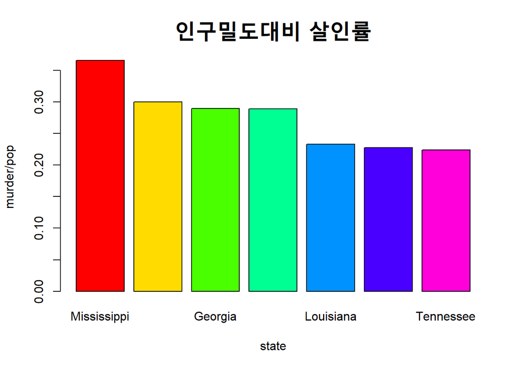

```r
USArrests_df <- USArrests
USArrests_df$ratio_mp <- USArrests_df$Murder/USArrests_df$UrbanPop
USArrests_df <- USArrests_df[order(USArrests_df$ratio_mp, decreasing=T),]
USArrests_df <- tibble::rownames_to_column(USArrests_df)

result <- head(USArrests_df,7)
barplot(result$ratio_mp,
        main="인구밀도대비 살인률",
        names.arg=result$rowname,
        xlab='state',
        ylab='murder/pop',
        col=rainbow(7),
        cex.main=2
        )
```

## **RegExpR**

> 정규표현식을 이용한 문자열 처리

```r
# install.packages('stringr')
library(stringr)
```

```r
str_extract("홍길동35이순신45유관순25", "[0-9]{2}")     # 맨 처음 등장하는 연속된 숫자 2개
```

```
## [1] "35"
```

```r
str_extract_all("홍길동35이순신45유관순25", "[0-9]{2}") # 모든 연속된 숫자 2개
```

```
## [[1]]
## [1] "35" "45" "25"
```

```r
unlist(str_extract_all("홍길동35이순신45유관순25", "[0-9]{2}"))
```

```
## [1] "35" "45" "25"
```

[실습] 반복수를 지정하여 영문자를 추출

```r
string <- 'hongkildong105lee1002you25강감찬2005'
str_extract_all(string, '[a-z]{3}')   # 3자
```

```
## [[1]]
## [1] "hon" "gki" "ldo" "lee" "you"
```

```r
str_extract_all(string, '[a-z]{3,}')  # 3자 이상
```

```
## [[1]]
## [1] "hongkildong" "lee"         "you"
```

```r
str_extract_all(string, '[a-z]{3,5}') # 3~5자
```

```
## [[1]]
## [1] "hongk" "ildon" "lee"   "you"
```

```r
string1 <- 'YEShongkildong105lee1002you25강감찬2005'
str_extract_all(string1, '[A-z]{3}')  # 3자(대문자 포함)
```

```
## [[1]]
## [1] "YES" "hon" "gki" "ldo" "lee" "you"
```

[실습] 한글, 영문자, 숫자 추출하기

```r
str_extract_all(string,'hong')
```

```
## [[1]]
## [1] "hong"
```

```r
str_extract_all(string,'25')
```

```
## [[1]]
## [1] "25"
```

```r
str_extract_all(string,'[가-힣]{3}')
```

```
## [[1]]
## [1] "강감찬"
```

[실습] 한글, 영문자, 숫자를 제외한 나머지 추출하기

```r
string1 <- 'YEShongkildong105lee1002you25강감찬2005'
jumin <- '123456-3234567654321-3589621'

# 소문자를 제외하고 추출
str_extract_all(string1, '[^a-z]{1,}')
```

```
## [[1]]
## [1] "YES"          "105"          "1002"         "25강감찬2005"
```

```r
# 소문자를 제외한 4연속 문자 추출
str_extract_all(string1, '[^a-z]{4}')
```

```
## [[1]]
## [1] "1002"   "25강감" "찬200"
```

```r
# 한글을 제외한 5연속 문자 추출
str_extract_all(string1, '[^가-힣]{5}')
```

```
## [[1]]
## [1] "YESho" "ngkil" "dong1" "05lee" "1002y"
```

```r
# 주민번호 형식에 맞게 추출해서 data frame화
df_jumin <- data.frame(jumin=unlist(str_extract_all(jumin,'[0-9]{6}-[0-9]{7}')))
df_jumin
```

```
##            jumin
## 1 123456-3234567
## 2 654321-3589621
```

[실습] 지정된 길이의 단어 추출하기

```r
name <- '홍길동1234,이순신5678,강감찬1012'
# 이름과 학번으로 분리해서 data frame화
df_student <- data.frame(name=unlist(str_extract_all(name,'[가-힣]{2,5}')),
                         studentID=unlist(str_extract_all(name,'[0-9]{4}')))
df_student
```

```
##     name studentID
## 1 홍길동      1234
## 2 이순신      5678
## 3 강감찬      1012
```

문자 대체하기

```r
gsub('영','0','홍영기')
```

```
## [1] "홍0기"
```

```r
mat <- matrix(1:6, ncol=2)
mat
```

```
##      [,1] [,2]
## [1,]    1    4
## [2,]    2    5
## [3,]    3    6
```

```r
a <- data.frame(mat, 7:9)
a   # c(7:9)를 이어붙임
```

```
##   X1 X2 X7.9
## 1  1  4    7
## 2  2  5    8
## 3  3  6    9
```

```r
b <- as.data.frame(mat, 7:9)
b   # c(7:9)가 행 이름이 됨
```

```
##   V1 V2
## 7  1  4
## 8  2  5
## 9  3  6
```